# Bookdown Demo

Ulrike Grömping

23 June 2020

# 1 First chapter

The R package **bookdown** is documented in an online book by its author Yihui Xie (2020). In this brief demo, I demonstrate some basic aspects of the use of the R package **bookdown** that took my some more time to figure out from that documentation.

You can have unnumbered chapters (while most chapters are numbered), see the appendix.

With the **bookdown** package, it is easy to reference back an forth between sections, and to figures or tables that were created from code chunks. References to figures start with “fig:”, references to tables with “tab:”, and section references are entirely defined in the curly brackets after the heading, starting with “#”. The syntax for **bookdown** references is “@ref(your reference target)”, see examples in this file. They are translated to the appropriate way of referencing for pdf or html files, as appropriate.

# 2 Second chapter

Table 2.1 shows the correlations in the dataset `swiss`.

```r
knitr::kable(round(cor(swiss),4), caption="The correlation matrix of the `swiss` data", booktabs=TRUE, linesep="")
```

Table 2.1: The correlation matrix of the `swiss` data

|  | Fertility | Agriculture | Examination | Education | Catholic | Infant.Mortality |
| --- | --- | --- | --- | --- | --- | --- |
| Fertility | 1.0000 | 0.3531 | -0.6459 | -0.6638 | 0.4637 | 0.4166 |
| Agriculture | 0.3531 | 1.0000 | -0.6865 | -0.6395 | 0.4011 | -0.0609 |
| Examination | -0.6459 | -0.6865 | 1.0000 | 0.6984 | -0.5727 | -0.1140 |
| Education | -0.6638 | -0.6395 | 0.6984 | 1.0000 | -0.1539 | -0.0993 |
| Catholic | 0.4637 | 0.4011 | -0.5727 | -0.1539 | 1.0000 | 0.1755 |
| Infant.Mortality | 0.4166 | -0.0609 | -0.1140 | -0.0993 | 0.1755 | 1.0000 |

Figure 2.1 shows a kernel density estimate of the proportion of males involved in agricultural occupations.

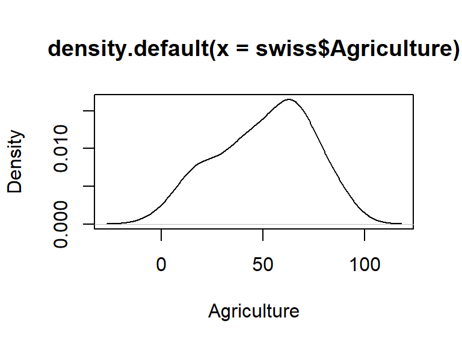

Figure 2.1: Proportion of males involved in agricultural occupations in 47 French speaking swiss provinces (1888). Kernel density estimate.

```r
plot(density(swiss$Agriculture), xlab="Agriculture")
```

# 3 Third chapter

Figure 3.1 shows a scatter plot with a more demanding figure caption.

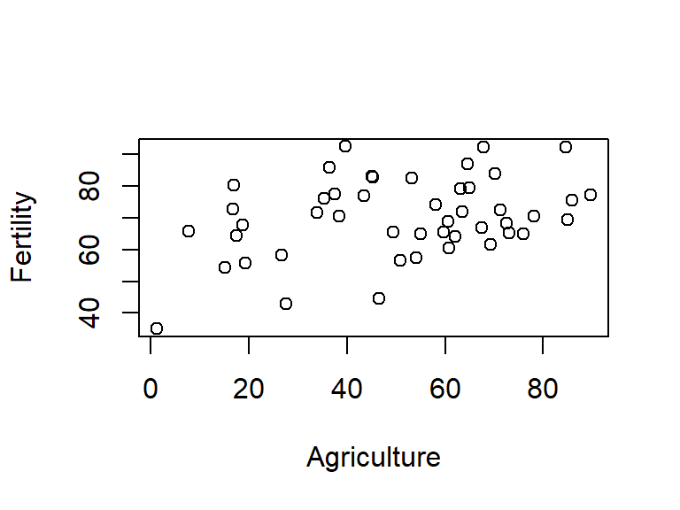

Figure 3.1: A caption can contain *underscores* and $\sqrt v$ formulae.

```r
plot(Fertility~Agriculture, swiss)
```

# 4 Final chapter

Your final chapter like your introductury chapter will be read by every reader. Both these chapters are therefore particularly important.

Please note that this brief text focused on how to implement a report with the help of R package **bookdown**. There was not content of specific relevance for data visualization.

# References

Xie, Y. (2020). bookdown: Authoring Books and Technical Documents with R Mardown. https://bookdown.org/yihui/bookdown/ (Status: June 17, 2020).

# Appendix A

Example for an appendix

The following listing shows the data (do not do that with a large data set!).

```r
print(swiss)
```

```
##              Fertility Agriculture Examination Education Catholic
## Courtelary        80.2        17.0          15        12     9.96
## Delemont          83.1        45.1           6         9    84.84
## Franches-Mnt      92.5        39.7           5         5    93.40
## Moutier           85.8        36.5          12         7    33.77
## Neuveville        76.9        43.5          17        15     5.16
## Porrentruy        76.1        35.3           9         7    90.57
## Broye             83.8        70.2          16         7    92.85
## Glane             92.4        67.8          14         8    97.16
## Gruyere           82.4        53.3          12         7    97.67
## Sarine            82.9        45.2          16        13    91.38
## Veveyse           87.1        64.5          14         6    98.61
## Aigle             64.1        62.0          21        12     8.52
## Aubonne           66.9        67.5          14         7     2.27
## Avenches          68.9        60.7          19        12     4.43
## Cossonay          61.7        69.3          22         5     2.82
## Echallens         68.3        72.6          18         2    24.20
## Grandson          71.7        34.0          17         8     3.30
## Lausanne          55.7        19.4          26        28    12.11
## La Vallee         54.3        15.2          31        20     2.15
## Lavaux            65.1        73.0          19         9     2.84
## Morges            65.5        59.8          22        10     5.23
## Moudon            65.0        55.1          14         3     4.52
## Nyone             56.6        50.9          22        12    15.14
## Orbe              57.4        54.1          20         6     4.20
## Oron              72.5        71.2          12         1     2.40
## Payerne           74.2        58.1          14         8     5.23
## Paysd'enhaut      72.0        63.5           6         3     2.56
## Rolle             60.5        60.8          16        10     7.72
## Vevey             58.3        26.8          25        19    18.46
## Yverdon           65.4        49.5          15         8     6.10
## Conthey           75.5        85.9           3         2    99.71
## Entremont         69.3        84.9           7         6    99.68
## Herens            77.3        89.7           5         2   100.00
## Martigwy          70.5        78.2          12         6    98.96
## Monthey           79.4        64.9           7         3    98.22
## St Maurice        65.0        75.9           9         9    99.06
## Sierre            92.2        84.6           3         3    99.46
## Sion              79.3        63.1          13        13    96.83
## Boudry            70.4        38.4          26        12     5.62
```

[output cut: 41 more lines]

```
## Herens                   18.3
## Martigwy                 19.4
## Monthey                  20.2
## St Maurice               17.8
## Sierre                   16.3
## Sion                     18.1
## Boudry                   20.3
## La Chauxdfnd             20.5
## Le Locle                 18.9
## Neuchatel                23.0
## Val de Ruz               20.0
## ValdeTravers             19.5
## V. De Geneve             18.0
## Rive Droite              18.2
## Rive Gauche              19.3
```